# 10_exe

## **Autores**

Rodrigo Makoto Takumi RA: 176897

Carlos Augusto Jardim Chiarelli RA: 165685

$$ $$

## **10 - Projeto de controlador PID: Método Ziegler-Nichols**

Este trabalho foi desenvolvido em linguagem **"Python 3.7"**.

```python
# bibliotecas
import numpy as np
import sympy as sp
import matplotlib.pyplot       as plt
from   scipy.signal            import lsim, lti, step, impulse
from   IPython.core.pylabtools import figsize
from   IPython.display         import Image

figsize(12, 8)                         # tamanho gráficos
plt.rcParams.update({'font.size': 14}) # tamanho da fonte
sp.init_printing()                     # printar variáveis simbólicas
```

```python
def plotaResposta(t, saida, entrada, titulo, yLabel):
    # visulizando resposta
    plt.plot(t, saida,   label='y(t)', color='r')

    plt.title(titulo+' \n')
    plt.xlabel('\n Tempo (s)')
    plt.ylabel(yLabel +  '\n')
    plt.grid(color = 'b', alpha = 0.5, linestyle = 'dashed', linewidth = 0.5)
    plt.show()
```

# **Exercício 01**

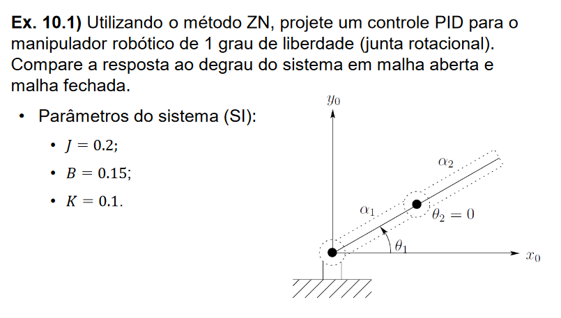

```python
Image('../dados/imagens/10_exe_1.png')
```

Apartir do DCL, temos:

$$$$$$ T(t) = J\ddot{\theta}(t) + B\dot{\theta}(t) + K\theta(t)$$$$$$

Aplicando a transformada de Laplace, temos:

$$$$$$ T(s) = Js^2\theta(s) + Bs\theta(s) + K\theta(s)$$$$$$

Assim, a função de transferência é:

$$$$$$ G(s) = \frac{\theta(s)}{T(s)} = \frac{\omega_{n}^2}{s^2 + 2\xi\omega_{n}s + \omega_{n}^2}$$$$$$

onde:

$$$$$$ \omega_{n} = \sqrt{\frac{K}{J}} $$$$$$$$ \xi = \frac{B}{2\sqrt{KJ}} $$$$$$

Assim, para J = 0.2, B = 0.15 e K = 0.1, temos:

$$$$$$ G(s) = \frac{0.5}{s^2 + 0.75s + 0.5} $$$$$$

```python
# Polos do sistema
np.roots([1, 0.75, 0.5])
```

```
array([-0.375+0.59947894j, -0.375-0.59947894j])
```

Aplicando a função root, temos que os polos do sistema são:

$$$$$$ s1 = -0.375 + 0.5995i $$$$ s2 = -0.375 - 0.5995i $$$$$$

Como temos um par de polos com parte real negativa, o sistema é estável.

$$$$

Para a constante de erro estátic, temos:

$$$$$$ K_{p} = \lim_{s -> 0}G(s) = G(0) = 1 $$$$$$

E o erro estacionário ao degrau é:

$$$$$$ e_{ss} = \lim_{s -> 0}\frac{1}{1 + G(s)} = \frac{1}{1 + K_{p}} = 0.5 $$$$$$

## **Resposta ao Degrau - Malha Aberta**

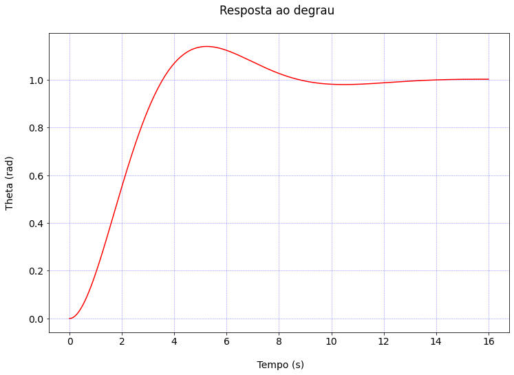

```python
# vetor de tempo
dt = 1e-3
tr  = np.arange(0, 16, dt) # tempo (0 a 16s)

numeradorFs = 0.5
denominadorFs = [1, 0.75, 0.5]

Fs = (numeradorFs, denominadorFs)

LTI = lti(numeradorFs, denominadorFs) # gerando o sistema

t_stepGs, y_stepGs = step(LTI, T=tr)      # resposta ao degrau

r = np.ones(len(tr))

plotaResposta(t_stepGs, y_stepGs, r, 'Resposta ao degrau', 'Theta (rad)')
```

```python
L = 0.494
theta = 3.219 - L
```

Utilizando o médoto Ziegler-Nichols, temos para um controlador PID:

```python
kp = 1.2*theta/L
Ti = 2*L
Td = 0.247

print("kp = ", kp)
print("Ti = ", Ti)
print("Td = ", Td)
```

```
kp =  6.619433198380566
Ti =  0.988
Td =  0.247
```

$$ $$

Como

$$$$$$ K(s) = k_{p} \left(1 + \frac{1}{T_{i}s} + T_{d}s \right) $$$$$$

Considerando os valores de kp, Ti e Td, temos:

$$$$$$ K(s) = 6.619 \left( 1 + \frac{1}{0.988s} + 0.247s \right) $$$$$$

Como H(s) e G(s) são, respectivamentes:

$$$$$$ H(s) = \frac{K(s)G(s)}{1 + K(s)G(s)} $$$$$$$$ G(s) = \frac{0.5}{s^2 + 0.75s + 0.5} $$$$$$

```python
# manipulação simbólica (álgebra)
s = sp.symbols('s') # variáveis

Gs = 0.5/(s*s +0.75*s + 0.5)

sp.factor(Gs, s)
```

$\displaystyle \frac{0.5}{1.0 s^{2} + 0.75 s + 0.5}$

Acima temos a função de transferência $G(s)$ do sistema em malha aberta sem controlador. $$$$

```python
Ks = kp*(1 + 1/(Ti*s) + Td*s)
Hs = (Gs*Ks)/(1 + Gs*Ks)

sp.factor(Hs, s)
```

$\displaystyle \frac{0.879308341974039 \left(0.244036 s^{2} + 0.988 s + 1.0\right)}{0.262486716259299 s^{3} + 0.411447927736451 s^{2} + 1.0 s + 0.879308341974039}$

$$$$

Acima temos a função de transferência $H(s)$ do sistema em malha fechada com controlador e baixo o numerado dessa $H(s)$ expandido. $$$$

```python
sp.expand(0.879308341974039*(0.244036*𝑠**2+0.988*𝑠+1.0))
```

$\displaystyle 0.214582890541977 s^{2} + 0.868756641870351 s + 0.879308341974039$

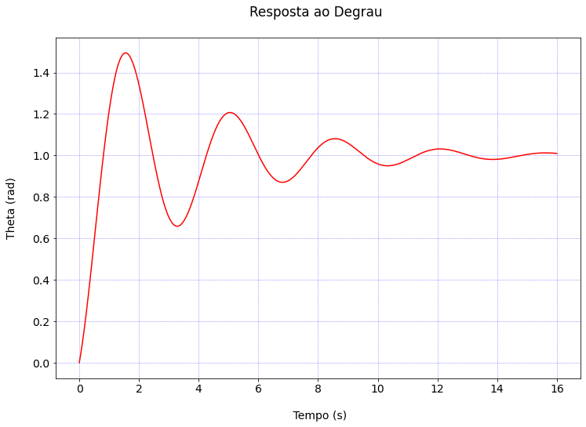

```python
numeradorFsPID   = [0.21458, 0.86875, 0.87930]
denominadorFsPID = [0.26248, 0.41144, 1, 0.87930]

Fs = (numeradorFsPID, denominadorFsPID)

LTI = lti(numeradorFsPID, denominadorFsPID) # gerando o sistema

tPID_step, yPID_step = step(LTI, T=tr)      # resposta ao degrau

r = np.ones(len(tr))

plotaResposta(tPID_step, yPID_step, r, 'Resposta ao Degrau','Theta (rad)')
```

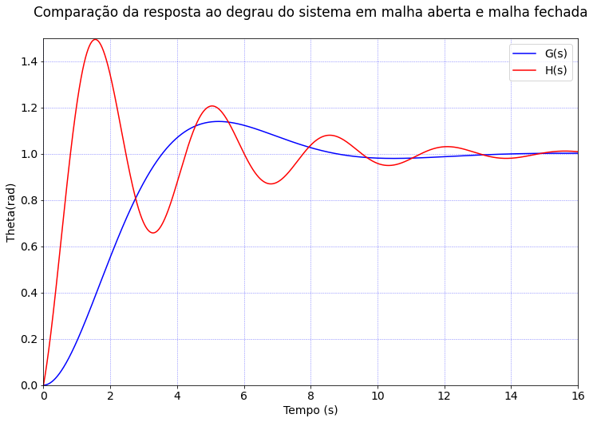

```python
plt.plot(t_stepGs, y_stepGs, label='G(s)', color='blue')
plt.plot(tPID_step, yPID_step, label='H(s)', color='red')
plt.ylim([0, 1.5])
plt.xlim([0,16])
plt.title('Comparação da resposta ao degrau do sistema em malha aberta e malha fechada\n')
plt.xlabel('Tempo (s)')
plt.ylabel('Theta(rad)')
plt.grid(color = 'b', alpha = 0.5, linestyle = 'dashed', linewidth = 0.5)
plt.legend()
plt.show()
```

$$$$

# **Exercício 02**

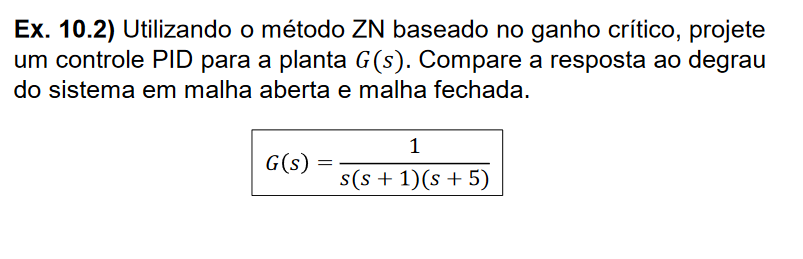

```python
Image('../dados/imagens/10_exe_2.png')
```

Sabendo-se que:

$$ G(s) = \frac{1}{s(s + 1)(s + 5)} $$$$$$

Temos:

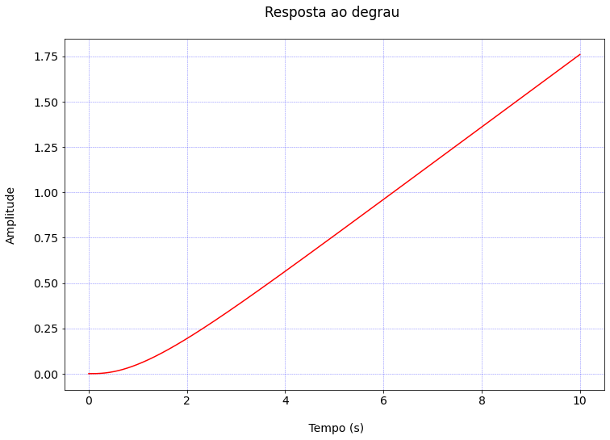

```python
# vetor de tempo
dt = 1e-3
tr  = np.arange(0, 10, dt)

numeradorFs = 1
denominadorFs = [1, 6, 5, 0]

Fs = (numeradorFs, denominadorFs)

LTI = lti(numeradorFs, denominadorFs) # gerando o sistema

t_step, y_step = step(LTI, T=tr)      # resposta ao degrau

r = np.ones(len(tr))

plotaResposta(t_step, y_step, r, 'Resposta ao degrau', 'Amplitude')
```

Função de transferência – malha fechada com ganho K:

$$$$$$ H(s) = \frac{K(s)G(s)}{1 + K(s)G(s)} $$$$$$$$ s^3 + 6s^2 + 5s + K = 0 $$

**Aplicando o critério R-H**

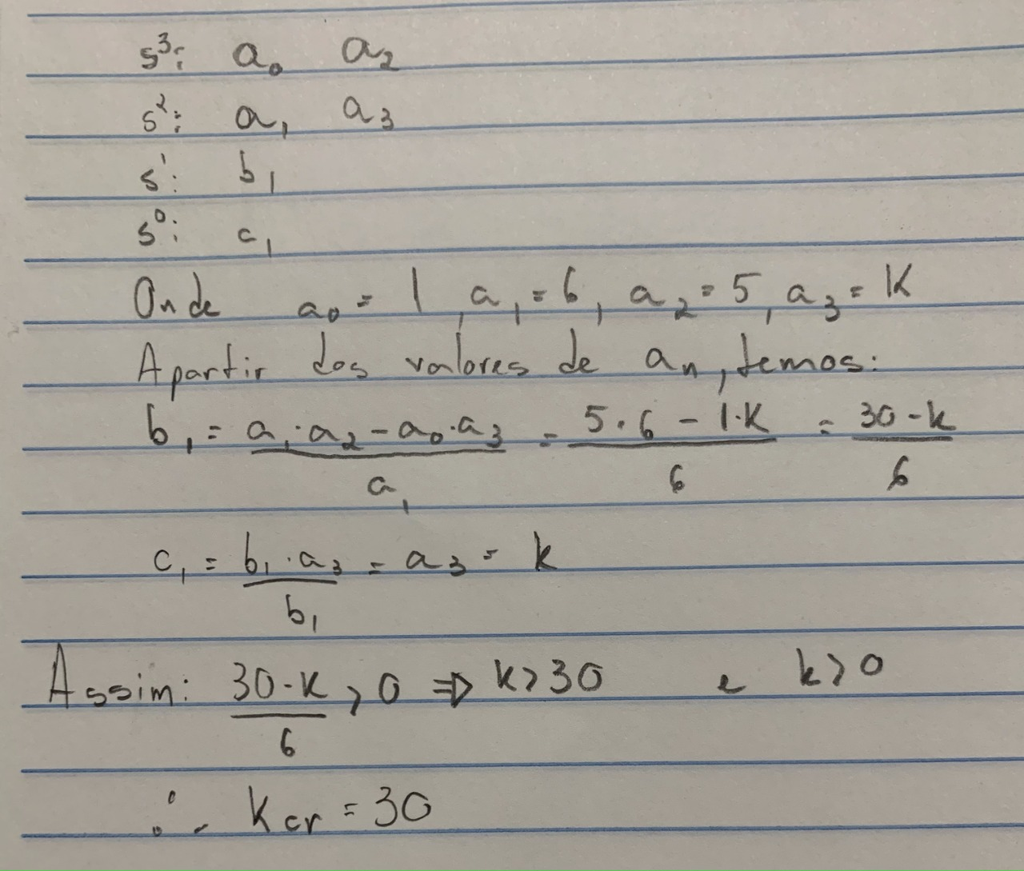

```python
Image('../dados/imagens/10_exe_3.jpeg')
```

```python
K = Kcr = 30

Gs = 1/(s*(s+1)*(s+5))
Hs = K*Gs/(1 + K*Gs)

sp.factor(Hs, s)
```

$\displaystyle \frac{30}{\left(s + 6\right) \left(s^{2} + 5\right)}$

$$$$

Acima temos a função de tansferência $H(s)$ e abaix o denomidador dela expandido. $$$$

```python
sp.expand((𝑠+6)*(𝑠**2+5))
```

$\displaystyle s^{3} + 6 s^{2} + 5 s + 30$

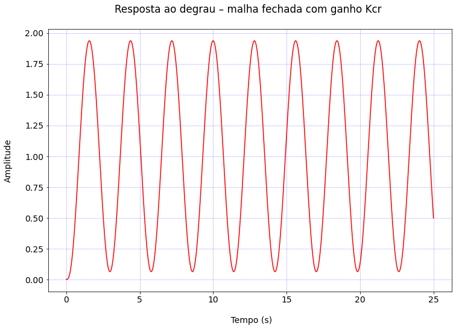

```python
tr  = np.arange(0, 25, dt)

numeradorFs = 30
denominadorFs = [1, 6, 5, 30]

Fs = (numeradorFs, denominadorFs)

LTI = lti(numeradorFs, denominadorFs) # gerando o sistema

t_step, y_step = step(LTI, T=tr)      # resposta ao degrau

r = np.ones(len(tr))

plotaResposta(t_step, y_step, r, 'Resposta ao degrau – malha fechada com ganho Kcr', 'Amplitude')
```

```python
# manipulação simbólica (álgebra)
s = sp.symbols('s')

kp = 18
ki = 12.86
kd = 6.3
```

```python
Ks = kp + ki/s + kd*s

sp.factor(Ks, s)
```

$\displaystyle \frac{18.0 \left(0.35 s^{2} + 1.0 s + 0.714444444444444\right)}{s}$

```python
Hs = Ks*Gs/(1 + Ks*Gs)

sp.factor(Hs, s)
```

$\displaystyle \frac{1.0 \left(0.35 s^{2} + 1.0 s + 0.714444444444444\right)}{0.0555555555555556 s^{4} + 0.333333333333333 s^{3} + 0.627777777777778 s^{2} + 1.0 s + 0.714444444444444}$

$$$$

Acima temos a função de transferência para o sistema em malha fechada com controlador. $$$$

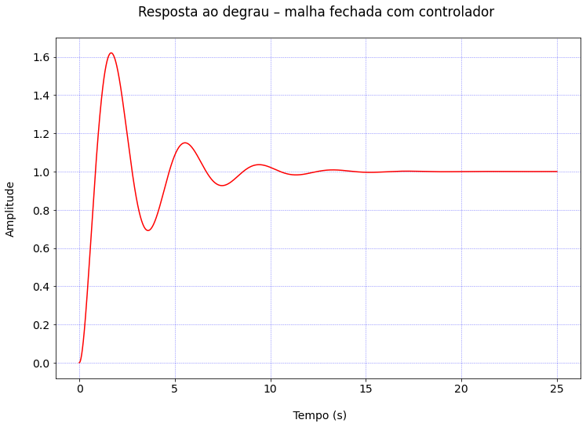

```python
numeradorFs   = [0.35, 1, 0.714444]
denominadorFs = [0.05555, 0.33333, 0.627777, 1, 0.7144444]

Fs = (numeradorFs, denominadorFs)

LTI = lti(numeradorFs, denominadorFs) # gerando o sistema

t_step, y_step = step(LTI, T=tr)      # resposta ao degrau

r = np.ones(len(tr))

plotaResposta(t_step, y_step, r, 'Resposta ao degrau – malha fechada com controlador', 'Amplitude')
```